# 550_Practice with Correlation

# Practice with Correlation

The `mortgagedefault.csv` is posted on Brightspace in this module.

```r
# Load the CSV
mortgage <- read.csv("mortgagedefault.csv")
```

```r
# View the first few rows
summary(mortgage)
```

```
  customer_id          Age        marital_status     annual_income    mortgage_amount  payments_per_year total_amount_paid default_status
 Min.   :  1.00   Min.   :19.00   Length:300         Min.   : 16598   Min.   :150616   Min.   : 4.0      Min.   : 171290   Length:300
 1st Qu.: 75.75   1st Qu.:31.75   Class :character   1st Qu.: 68029   1st Qu.:214562   1st Qu.:12.0      1st Qu.: 323121   Class :character
 Median :150.50   Median :35.00   Mode  :character   Median : 87360   Median :256572   Median :12.0      Median : 403526   Mode  :character
 Mean   :150.50   Mean   :34.73                      Mean   : 92693   Mean   :279864   Mean   :13.8      Mean   : 451356
 3rd Qu.:225.25   3rd Qu.:38.00                      3rd Qu.:109331   3rd Qu.:311450   3rd Qu.:15.0      3rd Qu.: 524874
 Max.   :300.00   Max.   :51.00                      Max.   :224900   Max.   :634610   Max.   :24.0      Max.   :1249696
```

```r
head(mortgage)
```

|  | customer_id | Age | marital_status | annual_income | mortgage_amount | payments_per_year | total_amount_paid | default_status |
| --- | --- | --- | --- | --- | --- | --- | --- | --- |
| 1 | 1 | 37 | SINGLE | 172125.70 | 473403.0 | 24 | 581885.1 | YES |
| 2 | 2 | 31 | SINGLE | 108571.04 | 300468.6 | 12 | 489320.4 | NO |
| 3 | 3 | 37 | MARRIED | 124136.41 | 330664.2 | 24 | 493541.9 | YES |
| 4 | 4 | 24 | MARRIED | 79614.04 | 230222.9 | 24 | 449682.1 | YES |
| 5 | 5 | 27 | SINGLE | 68087.33 | 282203.5 | 12 | 520581.8 | NO |
| 6 | 6 | 30 | MARRIED | 59959.80 | 251242.7 | 24 | 356711.6 | YES |

Use the code chunk below to investigate the data set. Feel free to add additional code chunks.

1. Find the correlation between a person’s annual income and the amount of their mortgage in this data set. What does this value tell you?

```r
income <- mortgage$annual_income
amount<- mortgage$mortgage_amount
cor(income, amount)
```

```
[1] 0.8536203
```

```r
# Create scatterplot
plot(amount,                    # variable on x-axis
     income,                        # variable on y-axis
     pch = 16,                    # filled-in circles
     cex = 1,                     # larger circle size
    # las = 3,                     # rotate numbers on y-axis
     xlab = "Income",           # x-axis label
     ylab = "Mortgage Amount") # y-axis label
```

[output not shown]

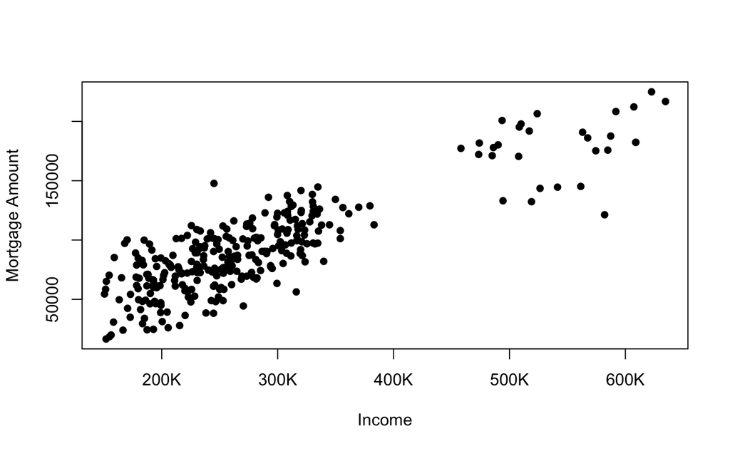

```r
# Avoid scientific notation for numbers
options(scipen = 999)

# Plot without the x-axis drawn
plot(amount,
     income,
     pch = 16,
     cex = 1,
     xaxt = "n",                  # suppress default x-axis
     xlab = "Income",
     ylab = "Mortgage Amount")

# Add a custom x-axis
axis(1,
     at = seq(100000, 600000, by = 100000),
     labels = c("100K", "200K", "300K", "400K", "500K", "600K"))
```

3. If annual income was converted from dollars to pennies, would the correlation increase, decrease or remain the same?

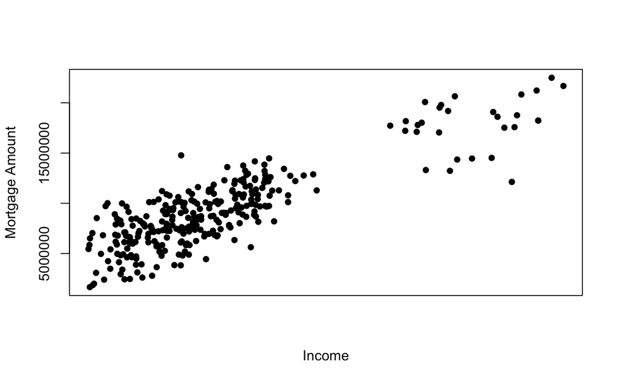

```r
#df$price_pennies <- df$price_dollars * 100
penn_income <- income * 100
plot(amount,
     penn_income,
     pch = 16,
     cex = 1,
     xaxt = "n",                  # suppress default x-axis
     xlab = "Income",
     ylab = "Mortgage Amount")
```

```r
NA
NA
```

4. What is wrong with the question, “Find the correlation between a person’s annual income and their default status”?
5. Calculate the correlation between a person’s age and their mortgage amount. What does this value tell you?
6. Calculate the correlation between a person’s age and their mortgage amount using the formula (with z-scores). Include comments in your code to show the step-by-step calculation.
7. True or False: A scatterplot with a correlation of r = 0.99 would be roughly linear in shape. Explain.
8. True or False: A scatterplot with a correlation of r = 0.01 would show no pattern at all. Explain.
9. Fill-in-the-blank: If you add a point outside the trend of a scatterplot, the correlation will ___ (strengthen, weaken, or remain the same?)
10. If we would like to determine if two categorical variables are associated, we should not use correlation, which requires quantitative variables. What could we do instead? Demonstrate below.
11. Why can’t you calculate the correlation of X and Y for the data shown below? Fix the issue and calculate the correlation. Does the correlation imply that the association is linear?

```r
X <- c(1, 2, 3, 4, NA, 6)
Y <- c(1, 4, 9, 16, NA, NA)
```